# Birthweights 1914 - 1922

# Birth weights

## Time series

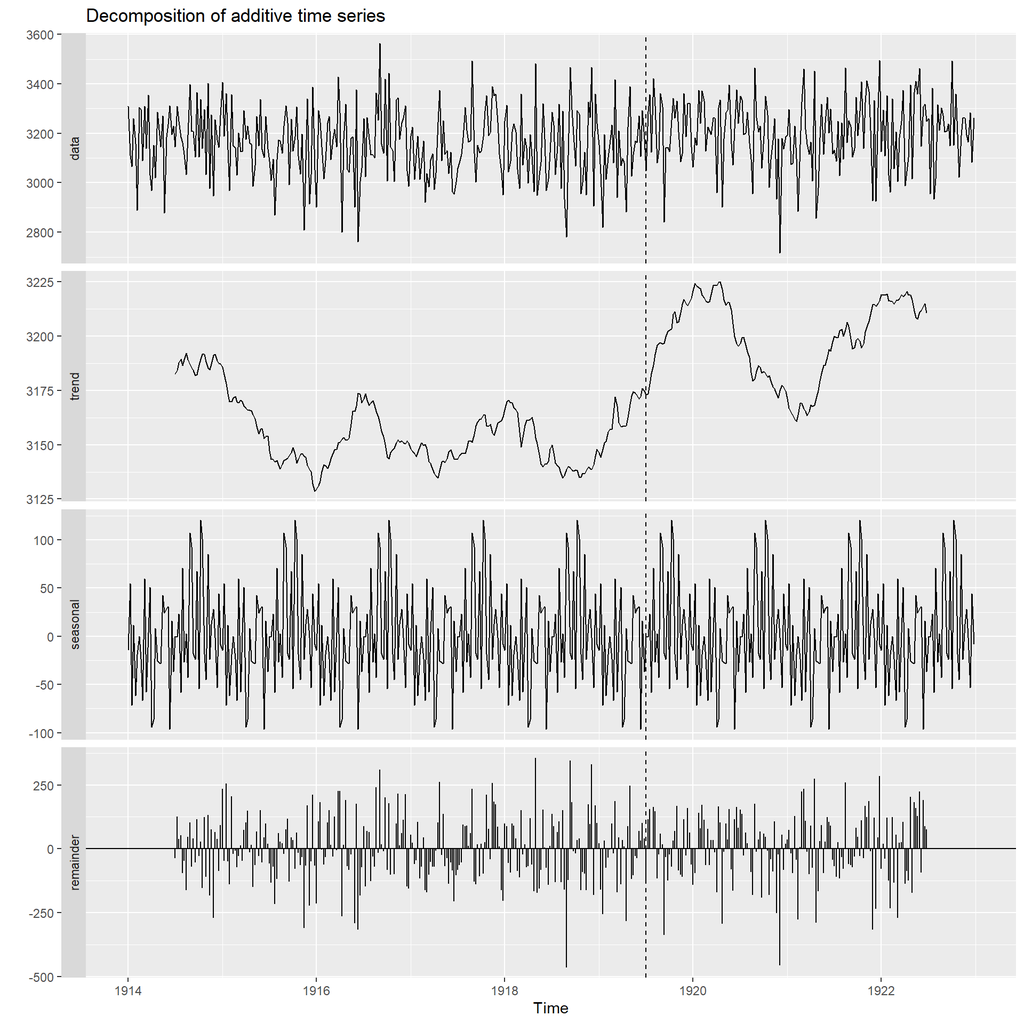

Gestational age, the differences are minimal (range: 39.6 - 40 weeks), there is no breakpoint.

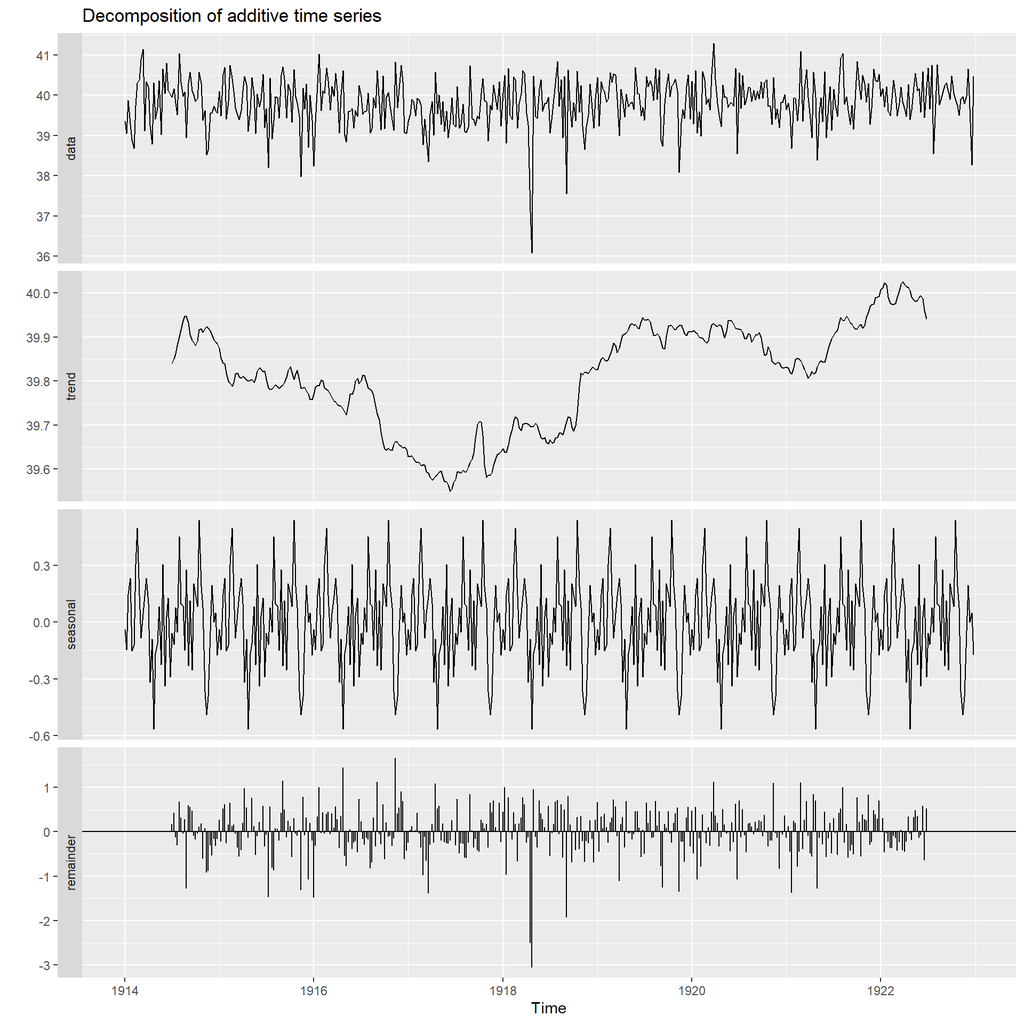

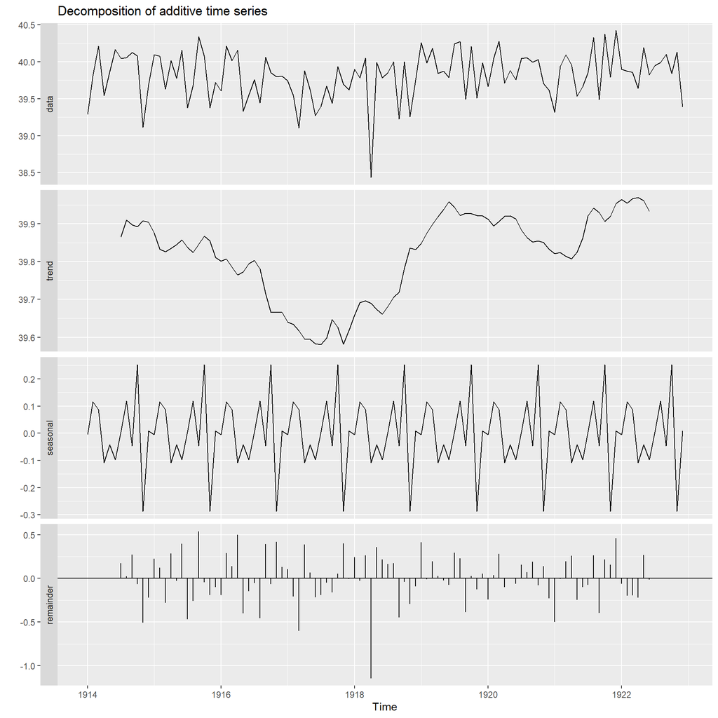

Stillborn = (sum of stillborn per week/sum birth per week) *100, no breakpoint, but more stillborns 1918/1919

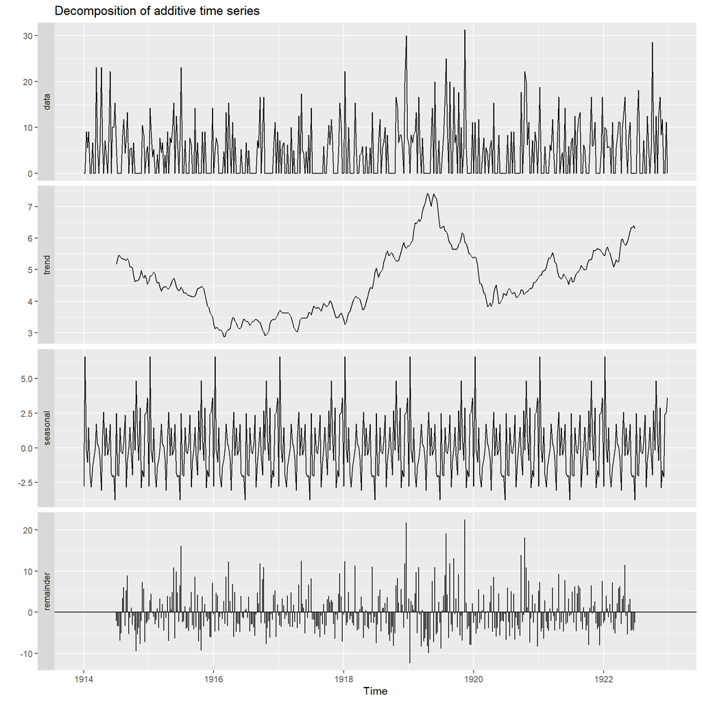

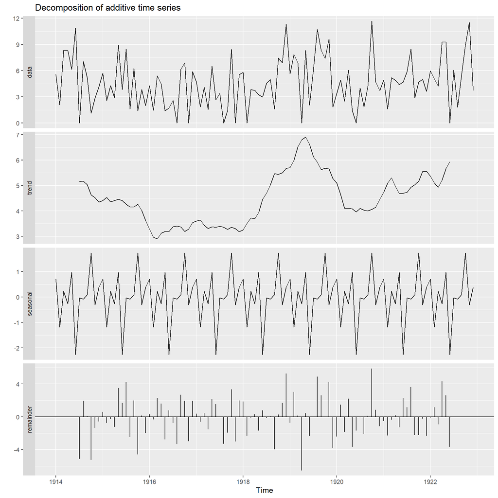

## unadjusted

The quantile regression does not provide any further information. The results are similar when using the quantile and linear regressions. No significant differences between the quantiles are found for the years 1918 and 1919.

### Quantile regression

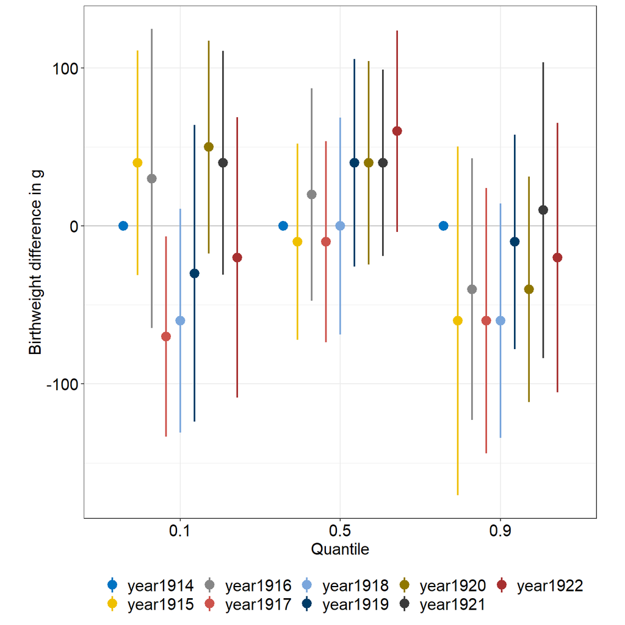

### Year

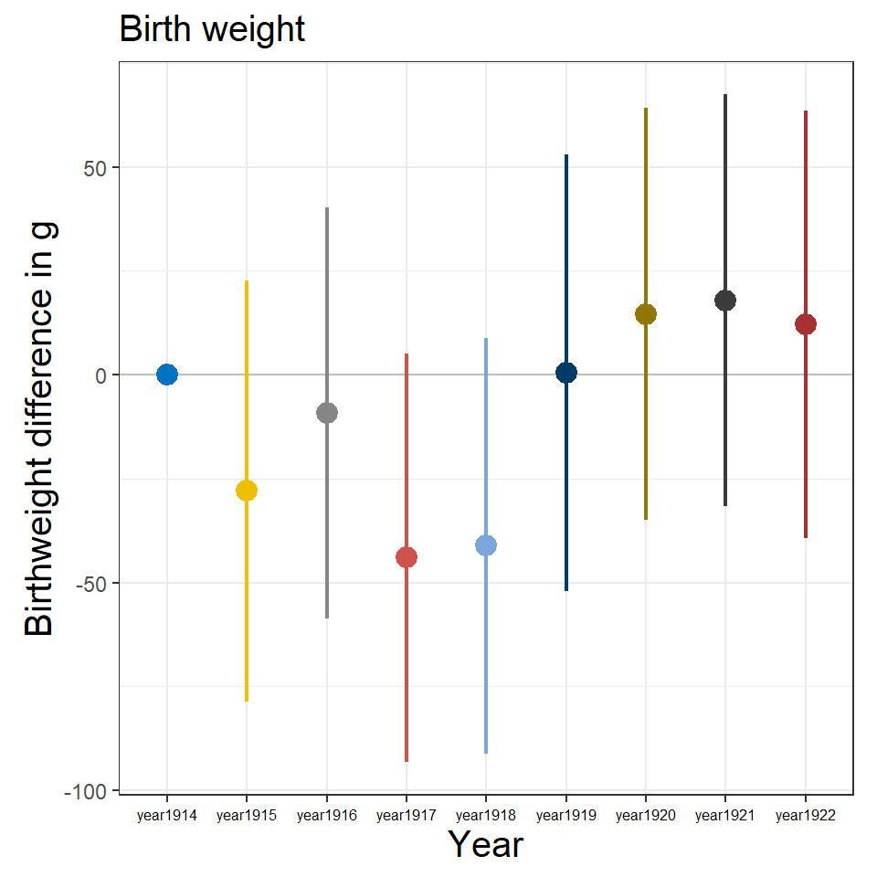

### Sex

```
##
## Call:
## lm(formula = formula, data = datared)
##
## Residuals:
##      Min       1Q   Median       3Q      Max
## -2175.58  -299.00     4.42   304.42  2014.42
##
## Coefficients:
##             Estimate Std. Error t value Pr(>|t|)
## (Intercept) 3245.582      8.337  389.31   <2e-16 ***
## boy0        -146.586     12.023  -12.19   <2e-16 ***
## ---
## Signif. codes:  0 '***' 0.001 '**' 0.01 '*' 0.05 '.' 0.1 ' ' 1
##
## Residual standard error: 488.3 on 6606 degrees of freedom
##   (1 Beobachtung als fehlend gelöscht)
## Multiple R-squared:  0.02201,    Adjusted R-squared:  0.02186
## F-statistic: 148.6 on 1 and 6606 DF,  p-value: < 2.2e-16
```

### Gestational age

```
##
## Call:
## lm(formula = formula, data = datared)
##
## Residuals:
##      Min       1Q   Median       3Q      Max
## -1814.91  -303.37   -13.37   296.63  2305.09
##
## Coefficients:
##                 Estimate Std. Error t value Pr(>|t|)
## (Intercept)     3233.374      6.323   511.4   <2e-16 ***
## Gest_groupearly -388.465     16.320   -23.8   <2e-16 ***
## ---
## Signif. codes:  0 '***' 0.001 '**' 0.01 '*' 0.05 '.' 0.1 ' ' 1
##
## Residual standard error: 473.9 on 6607 degrees of freedom
## Multiple R-squared:  0.07898,    Adjusted R-squared:  0.07885
## F-statistic: 566.6 on 1 and 6607 DF,  p-value: < 2.2e-16
```

### Birth month

```
##
## Call:
## lm(formula = formula, data = datared)
##
## Residuals:
##      Min       1Q   Median       3Q      Max
## -2165.12  -310.79     2.17   313.98  2088.73
##
## Coefficients:
##               Estimate Std. Error t value Pr(>|t|)
## (Intercept)   3171.275     20.922 151.575   <2e-16 ***
## birth_month2   -28.580     29.820  -0.958    0.338
## birth_month3    -1.939     28.938  -0.067    0.947
## birth_month4   -21.691     29.655  -0.731    0.465
## birth_month5    -7.846     29.306  -0.268    0.789
## birth_month6    10.051     29.992   0.335    0.738
## birth_month7   -10.489     29.381  -0.357    0.721
## birth_month8    24.745     30.110   0.822    0.411
## birth_month9    17.773     29.669   0.599    0.549
## birth_month10   36.555     29.483   1.240    0.215
## birth_month11   23.843     30.006   0.795    0.427
## birth_month12    5.944     30.309   0.196    0.845
## ---
## Signif. codes:  0 '***' 0.001 '**' 0.01 '*' 0.05 '.' 0.1 ' ' 1
##
## Residual standard error: 493.8 on 6597 degrees of freedom
## Multiple R-squared:  0.001443,   Adjusted R-squared:  -0.0002216
## F-statistic: 0.8669 on 11 and 6597 DF,  p-value: 0.5726
```

### Maternal age

```
##
## Call:
## lm(formula = formula, data = datared)
##
## Residuals:
##      Min       1Q   Median       3Q      Max
## -2274.00  -302.81     6.08   309.44  2044.94
##
## Coefficients:
##              Estimate Std. Error t value Pr(>|t|)
## (Intercept) 2930.4771    27.0856 108.193   <2e-16 ***
## matage         8.8933     0.9601   9.263   <2e-16 ***
## ---
## Signif. codes:  0 '***' 0.001 '**' 0.01 '*' 0.05 '.' 0.1 ' ' 1
##
## Residual standard error: 490.6 on 6607 degrees of freedom
## Multiple R-squared:  0.01282,    Adjusted R-squared:  0.01267
## F-statistic:  85.8 on 1 and 6607 DF,  p-value: < 2.2e-16
```

### Married

```
##
## Call:
## lm(formula = formula, data = datared)
##
## Residuals:
##      Min       1Q   Median       3Q      Max
## -2180.35  -306.18     3.82   309.65  2049.65
##
## Coefficients:
##             Estimate Std. Error t value Pr(>|t|)
## (Intercept) 3210.349      7.024 457.062   <2e-16 ***
## married0    -134.170     13.697  -9.796   <2e-16 ***
## ---
## Signif. codes:  0 '***' 0.001 '**' 0.01 '*' 0.05 '.' 0.1 ' ' 1
##
## Residual standard error: 490.2 on 6607 degrees of freedom
## Multiple R-squared:  0.01432,    Adjusted R-squared:  0.01417
## F-statistic: 95.96 on 1 and 6607 DF,  p-value: < 2.2e-16
```

### City

```
##
## Call:
## lm(formula = formula, data = datared)
##
## Residuals:
##      Min       1Q   Median       3Q      Max
## -2161.57  -310.38    -0.38   309.62  2099.62
##
## Coefficients:
##             Estimate Std. Error t value Pr(>|t|)
## (Intercept) 3160.377      8.346 378.691   <2e-16 ***
## city0         31.195     12.162   2.565   0.0103 *
## ---
## Signif. codes:  0 '***' 0.001 '**' 0.01 '*' 0.05 '.' 0.1 ' ' 1
##
## Residual standard error: 493.5 on 6607 degrees of freedom
## Multiple R-squared:  0.0009948,  Adjusted R-squared:  0.0008436
## F-statistic: 6.579 on 1 and 6607 DF,  p-value: 0.01034
```

### Insurance

```
##
## Call:
## lm(formula = formula, data = datared)
##
## Residuals:
##      Min       1Q   Median       3Q      Max
## -2138.99  -308.99     1.01   311.01  1981.01
##
## Coefficients:
##             Estimate Std. Error t value Pr(>|t|)
## (Intercept) 3168.994      6.216 509.774  < 2e-16 ***
## insurance1   125.802     28.295   4.446 8.89e-06 ***
## ---
## Signif. codes:  0 '***' 0.001 '**' 0.01 '*' 0.05 '.' 0.1 ' ' 1
##
## Residual standard error: 493 on 6607 degrees of freedom
## Multiple R-squared:  0.002983,   Adjusted R-squared:  0.002832
## F-statistic: 19.77 on 1 and 6607 DF,  p-value: 8.89e-06
```

### Flu Boxplot

Data range from 09.07.1918 – 02.02.1919  
Only multiple==0, matage > 50 and matage <14 were excluded

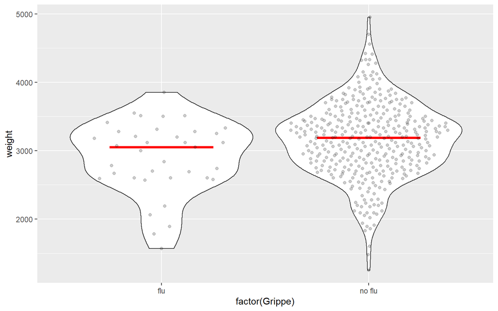

### Flu intensity

```
##
## Call:
## lm(formula = weight ~ Flu_intensity_all, data = datared)
##
## Residuals:
##      Min       1Q   Median       3Q      Max
## -2144.55  -310.87     5.45   315.45  2085.45
##
## Coefficients:
##                   Estimate Std. Error t value Pr(>|t|)
## (Intercept)       3174.554      6.392 496.609   <2e-16 ***
## Flu_intensity_all    8.654     33.680   0.257    0.797
## ---
## Signif. codes:  0 '***' 0.001 '**' 0.01 '*' 0.05 '.' 0.1 ' ' 1
##
## Residual standard error: 493.8 on 6607 degrees of freedom
## Multiple R-squared:  9.992e-06,  Adjusted R-squared:  -0.0001414
## F-statistic: 0.06601 on 1 and 6607 DF,  p-value: 0.7972
```

### Flu intensity - Quantile Regression

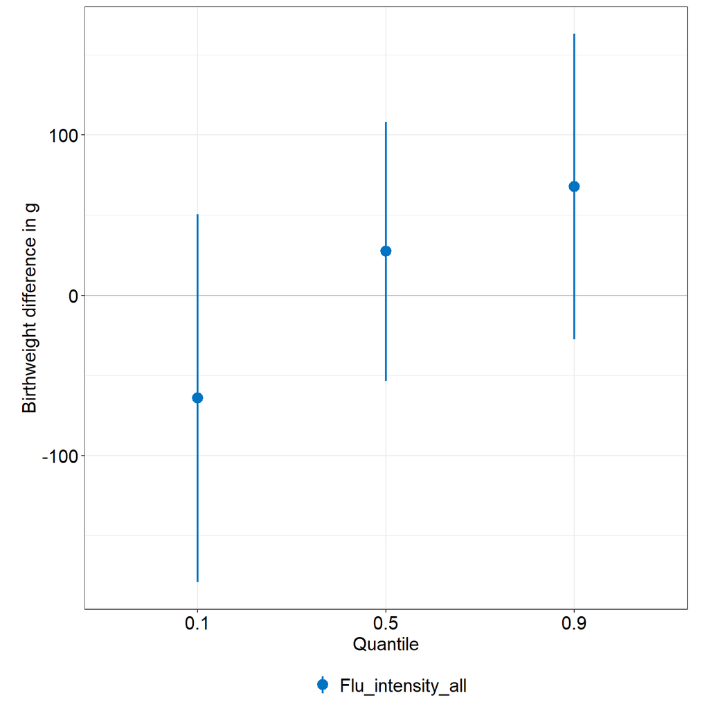

## adjusted

### Quantile regression

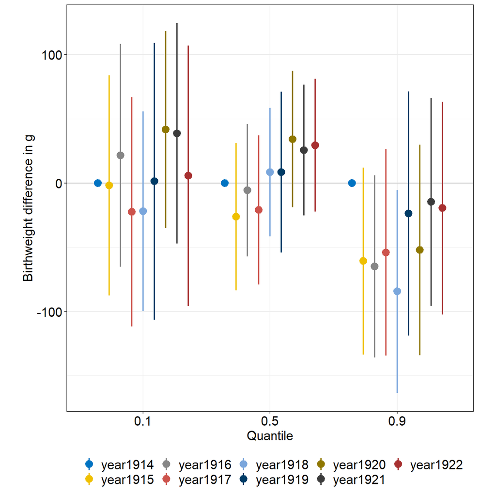

### Year

```
##
## Call:
## lm(formula = weight ~ year + boy + parity + Gest_group + birth_month +
##     matage + married + city + insurance, data = datared)
##
## Residuals:
##      Min       1Q   Median       3Q      Max
## -1930.15  -289.96    -0.23   288.91  2058.99
##
## Coefficients:
##                 Estimate Std. Error t value Pr(>|t|)
## (Intercept)     3243.480     39.464  82.188  < 2e-16 ***
## year1915         -22.513     24.000  -0.938   0.3482
## year1916         -10.111     23.403  -0.432   0.6657
## year1917         -28.137     23.260  -1.210   0.2264
## year1918         -20.011     23.729  -0.843   0.3991
## year1919         -11.414     24.814  -0.460   0.6456
## year1920          20.290     23.456   0.865   0.3871
## year1921          18.397     23.501   0.783   0.4338
## year1922          16.714     24.416   0.685   0.4937
## boy0            -148.640     11.270 -13.189  < 2e-16 ***
## parity2          131.084     15.563   8.423  < 2e-16 ***
## parity3          189.603     19.650   9.649  < 2e-16 ***
## parity>=4        241.358     18.455  13.078  < 2e-16 ***
## Gest_groupearly -376.666     15.875 -23.727  < 2e-16 ***
## birth_month2     -40.953     27.619  -1.483   0.1382
## birth_month3       1.152     26.791   0.043   0.9657
## birth_month4      -1.109     27.447  -0.040   0.9678
## birth_month5     -13.158     27.117  -0.485   0.6275
## birth_month6       0.108     27.751   0.004   0.9969
## birth_month7     -12.870     27.202  -0.473   0.6361
## birth_month8      12.790     27.894   0.459   0.6466
## birth_month9      -1.275     27.503  -0.046   0.9630
## birth_month10     29.142     27.318   1.067   0.2861
## birth_month11     41.332     27.819   1.486   0.1374
## birth_month12     -4.358     28.087  -0.155   0.8767
## matage            -1.827      1.130  -1.617   0.1060
## married0         -27.380     14.233  -1.924   0.0544 .
## city0             14.867     11.398   1.304   0.1922
## insurance1       148.453     26.994   5.499 3.95e-08 ***
## ---
## Signif. codes:  0 '***' 0.001 '**' 0.01 '*' 0.05 '.' 0.1 ' ' 1
##
## Residual standard error: 456.3 on 6562 degrees of freedom
##   (18 Beobachtungen als fehlend gelöscht)
## Multiple R-squared:  0.1477, Adjusted R-squared:  0.1441
## F-statistic: 40.62 on 28 and 6562 DF,  p-value: < 2.2e-16
```

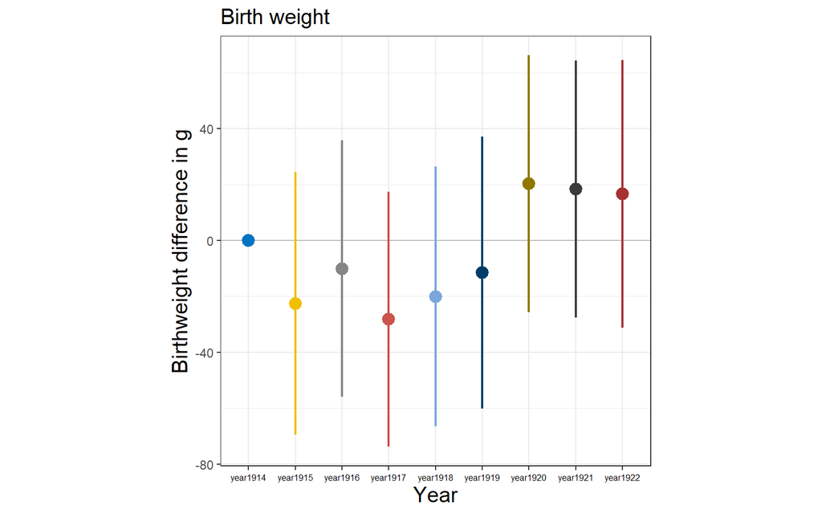

### Flu Intensity

```
##
## Call:
## lm(formula = weight ~ boy + parity + Gest_group + birth_month +
##     matage + married + city + insurance + Flu_intensity_all,
##     data = datared)
##
## Residuals:
##      Min       1Q   Median       3Q      Max
## -1934.56  -288.86    -0.88   285.79  2085.10
##
## Coefficients:
##                     Estimate Std. Error t value Pr(>|t|)
## (Intercept)        3.241e+03  3.627e+01  89.342  < 2e-16 ***
## boy0              -1.490e+02  1.127e+01 -13.224  < 2e-16 ***
## parity2            1.295e+02  1.554e+01   8.333  < 2e-16 ***
## parity3            1.858e+02  1.961e+01   9.479  < 2e-16 ***
## parity>=4          2.389e+02  1.843e+01  12.963  < 2e-16 ***
## Gest_groupearly   -3.791e+02  1.585e+01 -23.916  < 2e-16 ***
## birth_month2      -4.082e+01  2.761e+01  -1.478   0.1393
## birth_month3       1.143e+00  2.679e+01   0.043   0.9660
## birth_month4      -2.795e+00  2.744e+01  -0.102   0.9189
## birth_month5      -1.318e+01  2.710e+01  -0.486   0.6269
## birth_month6       1.101e-03  2.774e+01   0.000   1.0000
## birth_month7      -1.222e+01  2.719e+01  -0.450   0.6530
## birth_month8       1.143e+01  2.788e+01   0.410   0.6818
## birth_month9      -1.461e+00  2.749e+01  -0.053   0.9576
## birth_month10      2.724e+01  2.730e+01   0.998   0.3183
## birth_month11      4.093e+01  2.780e+01   1.472   0.1410
## birth_month12     -5.081e+00  2.807e+01  -0.181   0.8563
## matage            -1.780e+00  1.129e+00  -1.576   0.1150
## married0          -2.826e+01  1.422e+01  -1.988   0.0469 *
## city0              1.527e+01  1.139e+01   1.340   0.1803
## insurance1         1.520e+02  2.695e+01   5.640 1.77e-08 ***
## Flu_intensity_all -6.302e+00  3.125e+01  -0.202   0.8402
## ---
## Signif. codes:  0 '***' 0.001 '**' 0.01 '*' 0.05 '.' 0.1 ' ' 1
##
## Residual standard error: 456.4 on 6569 degrees of freedom
##   (18 Beobachtungen als fehlend gelöscht)
## Multiple R-squared:  0.1464, Adjusted R-squared:  0.1437
## F-statistic: 53.67 on 21 and 6569 DF,  p-value: < 2.2e-16
```

### Flu Intensity - Quantile Regression

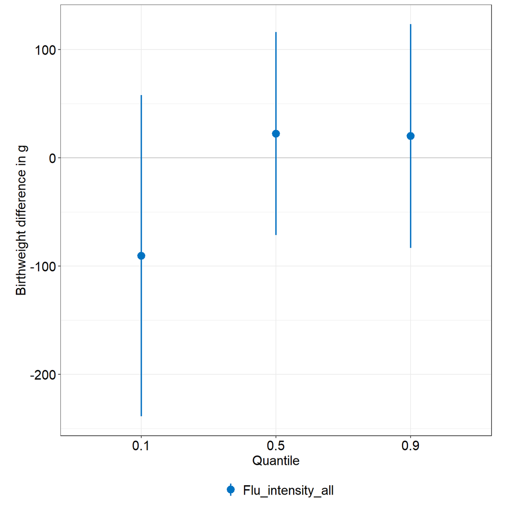

## Logistic Regression

<2500 g low birth weight

### unadjusted

Year

```
##
## Call:
## glm(formula = formula, family = binomial(link = "logit"), data = datared)
##
## Deviance Residuals:
##     Min       1Q   Median       3Q      Max
## -0.4282  -0.4198  -0.3754  -0.3468   2.3947
##
## Coefficients:
##             Estimate Std. Error z value Pr(>|z|)
## (Intercept) -2.78108    0.15535 -17.901   <2e-16 ***
## year1915     0.07151    0.21994   0.325   0.7451
## year1916     0.16382    0.21067   0.778   0.4368
## year1917     0.37358    0.20162   1.853   0.0639 .
## year1918     0.43779    0.20248   2.162   0.0306 *
## year1919     0.43323    0.21077   2.055   0.0398 *
## year1920    -0.02778    0.21962  -0.126   0.8993
## year1921     0.04367    0.21631   0.202   0.8400
## year1922     0.39625    0.20889   1.897   0.0578 .
## ---
## Signif. codes:  0 '***' 0.001 '**' 0.01 '*' 0.05 '.' 0.1 ' ' 1
##
## (Dispersion parameter for binomial family taken to be 1)
##
##     Null deviance: 3406.0  on 6608  degrees of freedom
## Residual deviance: 3390.9  on 6600  degrees of freedom
## AIC: 3408.9
##
## Number of Fisher Scoring iterations: 5
```

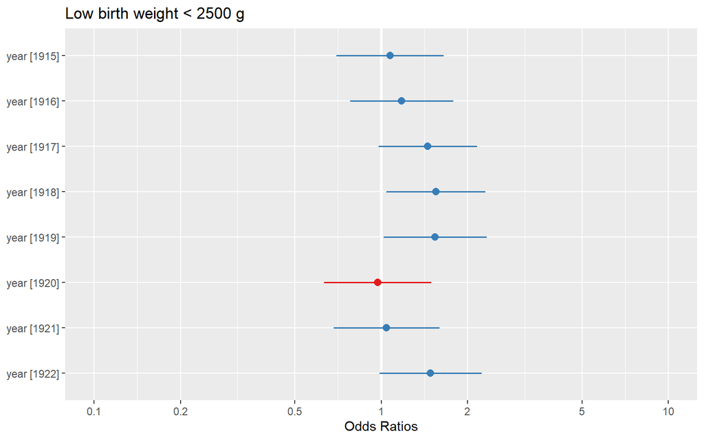

Flu

```
##
## Call:
## glm(formula = formula, family = binomial(link = "logit"), data = datared)
##
## Deviance Residuals:
##     Min       1Q   Median       3Q      Max
## -0.4536  -0.3803  -0.3803  -0.3803   2.3077
##
## Coefficients:
##                   Estimate Std. Error z value Pr(>|z|)
## (Intercept)       -2.59053    0.05075 -51.046   <2e-16 ***
## Flu_intensity_all  0.42332    0.23944   1.768   0.0771 .
## ---
## Signif. codes:  0 '***' 0.001 '**' 0.01 '*' 0.05 '.' 0.1 ' ' 1
##
## (Dispersion parameter for binomial family taken to be 1)
##
##     Null deviance: 3406.0  on 6608  degrees of freedom
## Residual deviance: 3403.1  on 6607  degrees of freedom
## AIC: 3407.1
##
## Number of Fisher Scoring iterations: 5
```

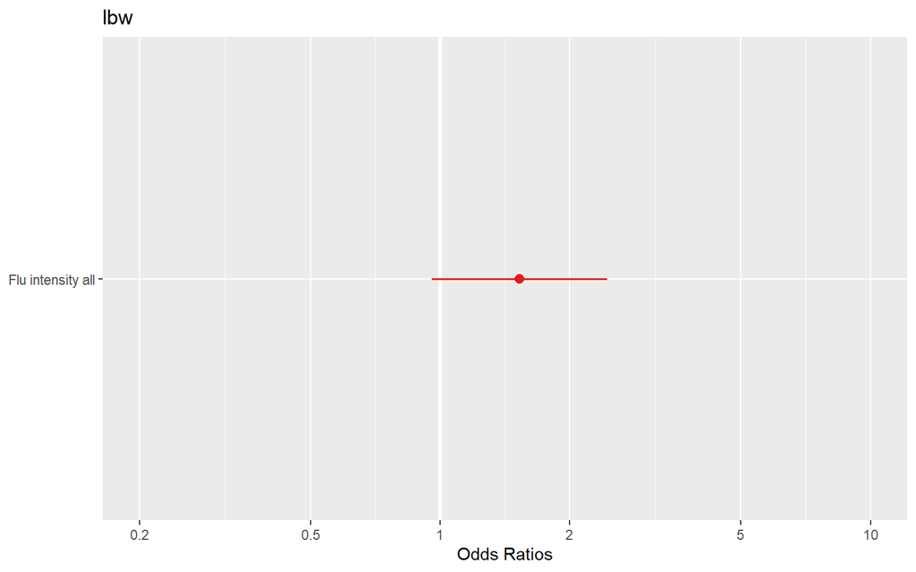

### adjusted

Year

```
##
## Call:
## glm(formula = formula, family = binomial(link = "logit"), data = datared)
##
## Deviance Residuals:
##     Min       1Q   Median       3Q      Max
## -0.7253  -0.4206  -0.3578  -0.2965   3.0275
##
## Coefficients:
##                Estimate Std. Error z value Pr(>|z|)
## (Intercept)   -3.417314   0.342026  -9.991  < 2e-16 ***
## year1915       0.012115   0.222934   0.054  0.95666
## year1916       0.148823   0.212442   0.701  0.48359
## year1917       0.395834   0.203521   1.945  0.05178 .
## year1918       0.400726   0.205140   1.953  0.05077 .
## year1919       0.441333   0.212812   2.074  0.03810 *
## year1920      -0.067677   0.221430  -0.306  0.75988
## year1921       0.022277   0.218525   0.102  0.91880
## year1922       0.373616   0.211338   1.768  0.07708 .
## boy0           0.455974   0.097720   4.666 3.07e-06 ***
## parity2       -0.334524   0.132599  -2.523  0.01164 *
## parity3       -0.749178   0.189967  -3.944 8.02e-05 ***
## parity>=4     -0.682566   0.161555  -4.225 2.39e-05 ***
## birth_month2   0.321394   0.217741   1.476  0.13993
## birth_month3  -0.194697   0.232071  -0.839  0.40149
## birth_month4   0.234009   0.217774   1.075  0.28258
## birth_month5   0.001471   0.225973   0.007  0.99481
## birth_month6  -0.182486   0.242633  -0.752  0.45199
## birth_month7   0.104296   0.221960   0.470  0.63843
## birth_month8  -0.277489   0.248823  -1.115  0.26476
## birth_month9  -0.500139   0.258563  -1.934  0.05308 .
## birth_month10 -0.294259   0.242442  -1.214  0.22485
## birth_month11  0.035442   0.230286   0.154  0.87768
## birth_month12 -0.288567   0.251204  -1.149  0.25067
## matage         0.028191   0.009471   2.977  0.00292 **
## married0       0.103621   0.115889   0.894  0.37125
## city0         -0.044442   0.098008  -0.453  0.65022
## insurance1    -0.526946   0.261641  -2.014  0.04401 *
## ---
## Signif. codes:  0 '***' 0.001 '**' 0.01 '*' 0.05 '.' 0.1 ' ' 1
##
## (Dispersion parameter for binomial family taken to be 1)
##
##     Null deviance: 3393.1  on 6590  degrees of freedom
## Residual deviance: 3296.9  on 6563  degrees of freedom
##   (18 Beobachtungen als fehlend gelöscht)
## AIC: 3352.9
##
## Number of Fisher Scoring iterations: 5
```

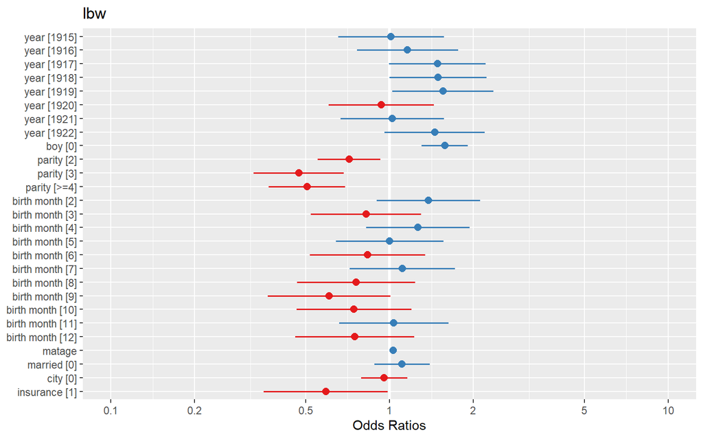

Flu

```
##
## Call:
## glm(formula = formula, family = binomial(link = "logit"), data = datared)
##
## Deviance Residuals:
##     Min       1Q   Median       3Q      Max
## -0.7272  -0.4205  -0.3592  -0.3037   2.9388
##
## Coefficients:
##                    Estimate Std. Error z value Pr(>|z|)
## (Intercept)       -3.226047   0.306128 -10.538  < 2e-16 ***
## boy0               0.454272   0.097579   4.655 3.23e-06 ***
## parity2           -0.340280   0.132119  -2.576  0.01001 *
## parity3           -0.742390   0.189599  -3.916 9.02e-05 ***
## parity>=4         -0.683329   0.161068  -4.242 2.21e-05 ***
## birth_month2       0.301929   0.217332   1.389  0.16476
## birth_month3      -0.194159   0.231730  -0.838  0.40211
## birth_month4       0.235613   0.217380   1.084  0.27842
## birth_month5      -0.003005   0.225535  -0.013  0.98937
## birth_month6      -0.161235   0.242178  -0.666  0.50556
## birth_month7       0.095393   0.221489   0.431  0.66669
## birth_month8      -0.274541   0.248422  -1.105  0.26910
## birth_month9      -0.493227   0.258312  -1.909  0.05621 .
## birth_month10     -0.288401   0.242013  -1.192  0.23339
## birth_month11      0.038801   0.229815   0.169  0.86593
## birth_month12     -0.280383   0.250751  -1.118  0.26349
## matage             0.027807   0.009423   2.951  0.00317 **
## married0           0.092295   0.115436   0.800  0.42398
## city0             -0.044206   0.097804  -0.452  0.65128
## insurance1        -0.522098   0.260983  -2.001  0.04545 *
## Flu_intensity_all  0.362327   0.239473   1.513  0.13028
## ---
## Signif. codes:  0 '***' 0.001 '**' 0.01 '*' 0.05 '.' 0.1 ' ' 1
##
## (Dispersion parameter for binomial family taken to be 1)
##
##     Null deviance: 3393.1  on 6590  degrees of freedom
## Residual deviance: 3311.1  on 6570  degrees of freedom
##   (18 Beobachtungen als fehlend gelöscht)
## AIC: 3353.1
##
## Number of Fisher Scoring iterations: 5
```

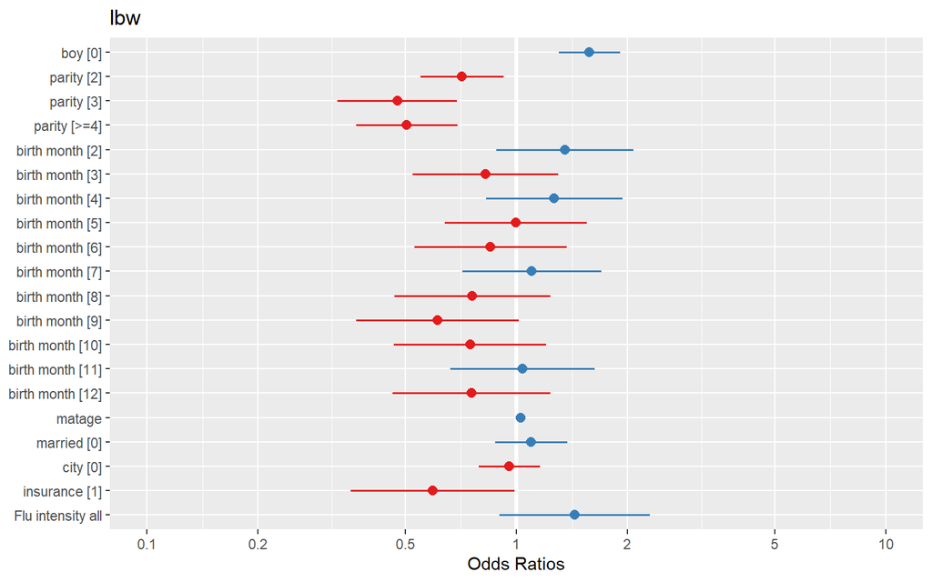

# Gestational age

| year | normal | early | total | perc_early |
| --- | --- | --- | --- | --- |
| 1914 | 648 | 106 | 754 | 14.06 |
| 1915 | 601 | 104 | 705 | 14.75 |
| 1916 | 662 | 117 | 779 | 15.02 |
| 1917 | 642 | 157 | 799 | 19.65 |
| 1918 | 611 | 131 | 742 | 17.65 |
| 1919 | 538 | 81 | 619 | 13.09 |
| 1920 | 675 | 99 | 774 | 12.79 |
| 1921 | 668 | 105 | 773 | 13.58 |
| 1922 | 572 | 92 | 664 | 13.86 |

I did the analysis with and without stillborns -> similar results. The results are shown with data without Stillborn. High multicollinearity between year and exposure sum and year and flu intensity. Therefor only one variable is used.

## unadjusted

### Year

```
##
## Call:
## glm(formula = formula, family = binomial(link = "logit"), data = datared_still_n)
##
## Deviance Residuals:
##     Min       1Q   Median       3Q      Max
## -0.6615  -0.5705  -0.5462  -0.5232   2.0280
##
## Coefficients:
##             Estimate Std. Error z value Pr(>|z|)
## (Intercept) -1.81045    0.10477 -17.280  < 2e-16 ***
## year1915     0.05625    0.14919   0.377  0.70615
## year1916     0.07736    0.14503   0.533  0.59376
## year1917     0.40211    0.13749   2.925  0.00345 **
## year1918     0.27055    0.14229   1.901  0.05725 .
## year1919    -0.08296    0.15869  -0.523  0.60113
## year1920    -0.10914    0.15020  -0.727  0.46744
## year1921    -0.03988    0.14832  -0.269  0.78804
## year1922    -0.01690    0.15361  -0.110  0.91240
## ---
## Signif. codes:  0 '***' 0.001 '**' 0.01 '*' 0.05 '.' 0.1 ' ' 1
##
## (Dispersion parameter for binomial family taken to be 1)
##
##     Null deviance: 5589.6  on 6608  degrees of freedom
## Residual deviance: 5565.7  on 6600  degrees of freedom
## AIC: 5583.7
##
## Number of Fisher Scoring iterations: 4
```

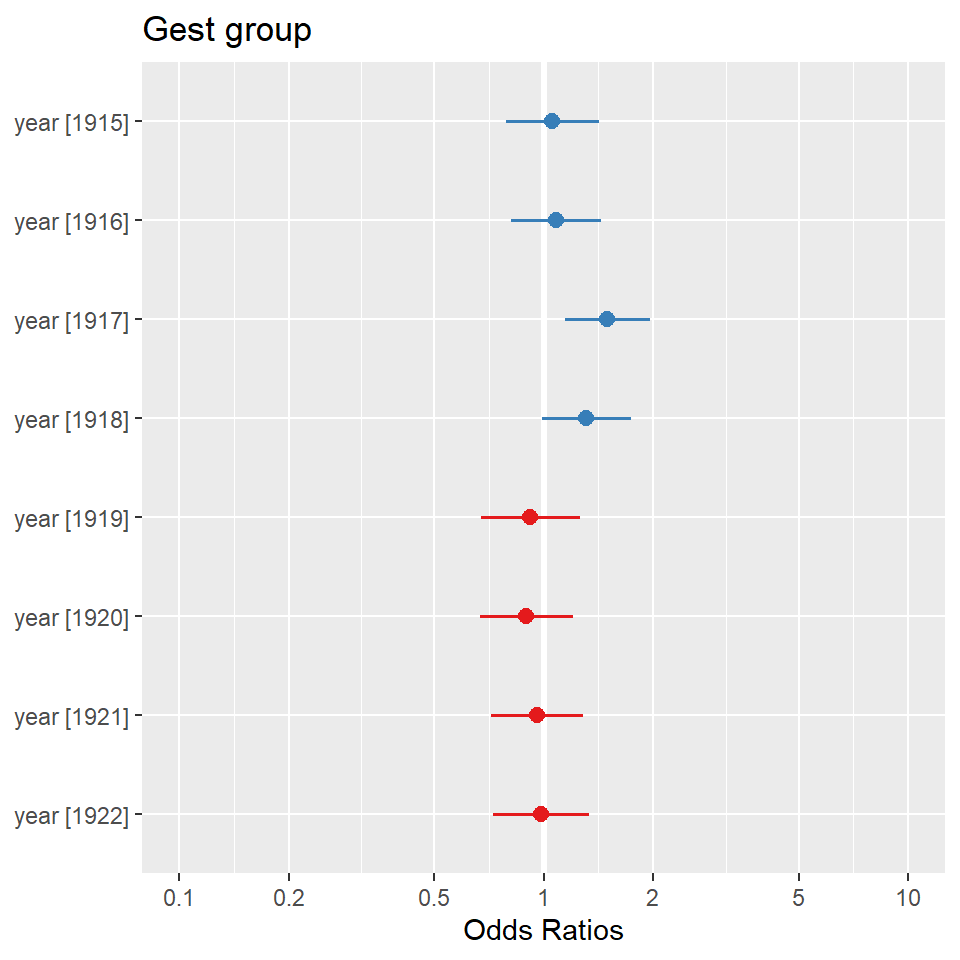

### Flu intensity

```
##
## Call:
## glm(formula = formula, family = binomial(link = "logit"), data = datared_still_n)
##
## Deviance Residuals:
##     Min       1Q   Median       3Q      Max
## -0.5758  -0.5758  -0.5758  -0.5640   2.0963
##
## Coefficients:
##                   Estimate Std. Error z value Pr(>|z|)
## (Intercept)       -1.71326    0.03603 -47.556   <2e-16 ***
## Flu_intensity_all -0.37368    0.20665  -1.808   0.0706 .
## ---
## Signif. codes:  0 '***' 0.001 '**' 0.01 '*' 0.05 '.' 0.1 ' ' 1
##
## (Dispersion parameter for binomial family taken to be 1)
##
##     Null deviance: 5589.6  on 6608  degrees of freedom
## Residual deviance: 5586.2  on 6607  degrees of freedom
## AIC: 5590.2
##
## Number of Fisher Scoring iterations: 4
```

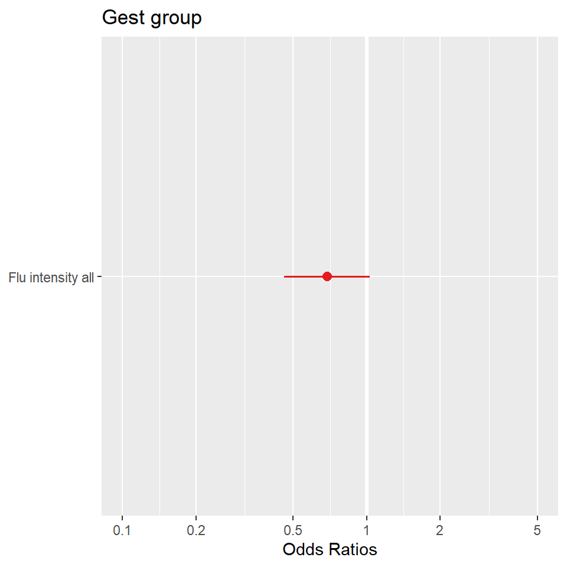

## adjusted

### Quantile regression

[figure not shown]

### Year

```
##
## Call:
## glm(formula = formula, family = binomial(link = "logit"), data = datared_still_n)
##
## Deviance Residuals:
##     Min       1Q   Median       3Q      Max
## -0.9192  -0.6021  -0.5317  -0.4598   2.3922
##
## Coefficients:
##                 Estimate Std. Error z value Pr(>|z|)
## (Intercept)   -1.4279776  0.2438988  -5.855 4.78e-09 ***
## year1915       0.0552971  0.1509888   0.366 0.714191
## year1916       0.0819989  0.1467094   0.559 0.576216
## year1917       0.4339110  0.1390694   3.120 0.001808 **
## year1918       0.2749070  0.1442025   1.906 0.056599 .
## year1919      -0.0851639  0.1601482  -0.532 0.594877
## year1920      -0.1000411  0.1517432  -0.659 0.509717
## year1921      -0.0480264  0.1506655  -0.319 0.749907
## year1922      -0.0004088  0.1553778  -0.003 0.997901
## boy0          -0.1044866  0.0698927  -1.495 0.134926
## parity2       -0.1422593  0.0980496  -1.451 0.146810
## parity3       -0.2802150  0.1303292  -2.150 0.031551 *
## parity>=4      0.0883388  0.1143295   0.773 0.439719
## birth_month2  -0.3067951  0.1746766  -1.756 0.079027 .
## birth_month3  -0.0533326  0.1612548  -0.331 0.740845
## birth_month4   0.1838205  0.1588888   1.157 0.247308
## birth_month5  -0.1408285  0.1650999  -0.853 0.393665
## birth_month6   0.0367931  0.1639732   0.224 0.822458
## birth_month7  -0.0852122  0.1647487  -0.517 0.604999
## birth_month8  -0.2609397  0.1749847  -1.491 0.135905
## birth_month9  -0.4355749  0.1786070  -2.439 0.014739 *
## birth_month10 -0.3767293  0.1744571  -2.159 0.030816 *
## birth_month11  0.2302827  0.1599303   1.440 0.149897
## birth_month12 -0.1993216  0.1735104  -1.149 0.250655
## city0         -0.0948795  0.0706328  -1.343 0.179182
## matage        -0.0086296  0.0071110  -1.214 0.224918
## married0       0.2932778  0.0847247   3.462 0.000537 ***
## insurance1    -0.1689079  0.1822658  -0.927 0.354076
## ---
## Signif. codes:  0 '***' 0.001 '**' 0.01 '*' 0.05 '.' 0.1 ' ' 1
##
## (Dispersion parameter for binomial family taken to be 1)
##
##     Null deviance: 5562.9  on 6590  degrees of freedom
## Residual deviance: 5467.7  on 6563  degrees of freedom
##   (18 Beobachtungen als fehlend gelöscht)
## AIC: 5523.7
##
## Number of Fisher Scoring iterations: 4
```

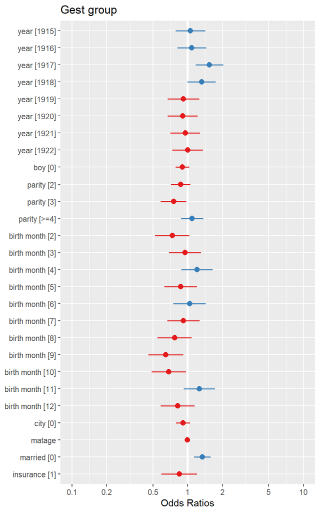

### Flu intensity

```
##
## Call:
## glm(formula = formula, family = binomial(link = "logit"), data = datared_still_n)
##
## Deviance Residuals:
##     Min       1Q   Median       3Q      Max
## -0.7971  -0.6026  -0.5389  -0.4722   2.3338
##
## Coefficients:
##                    Estimate Std. Error z value Pr(>|z|)
## (Intercept)       -1.323562   0.221741  -5.969 2.39e-09 ***
## boy0              -0.099109   0.069737  -1.421 0.155265
## parity2           -0.140442   0.097609  -1.439 0.150199
## parity3           -0.257179   0.129906  -1.980 0.047734 *
## parity>=4          0.097261   0.113751   0.855 0.392529
## birth_month2      -0.314649   0.174308  -1.805 0.071053 .
## birth_month3      -0.051186   0.160969  -0.318 0.750493
## birth_month4       0.199013   0.158513   1.256 0.209297
## birth_month5      -0.132389   0.164677  -0.804 0.421435
## birth_month6       0.048778   0.163522   0.298 0.765477
## birth_month7      -0.095567   0.164358  -0.581 0.560933
## birth_month8      -0.254239   0.174606  -1.456 0.145372
## birth_month9      -0.439792   0.178230  -2.468 0.013604 *
## birth_month10     -0.373154   0.173970  -2.145 0.031958 *
## birth_month11      0.213962   0.159432   1.342 0.179589
## birth_month12     -0.193820   0.172994  -1.120 0.262548
## city0             -0.095457   0.070491  -1.354 0.175679
## matage            -0.008848   0.007075  -1.251 0.211089
## married0           0.291189   0.084407   3.450 0.000561 ***
## insurance1        -0.184942   0.181649  -1.018 0.308618
## Flu_intensity_all -0.401352   0.205993  -1.948 0.051370 .
## ---
## Signif. codes:  0 '***' 0.001 '**' 0.01 '*' 0.05 '.' 0.1 ' ' 1
##
## (Dispersion parameter for binomial family taken to be 1)
##
##     Null deviance: 5562.9  on 6590  degrees of freedom
## Residual deviance: 5489.5  on 6570  degrees of freedom
##   (18 Beobachtungen als fehlend gelöscht)
## AIC: 5531.5
##
## Number of Fisher Scoring iterations: 4
```

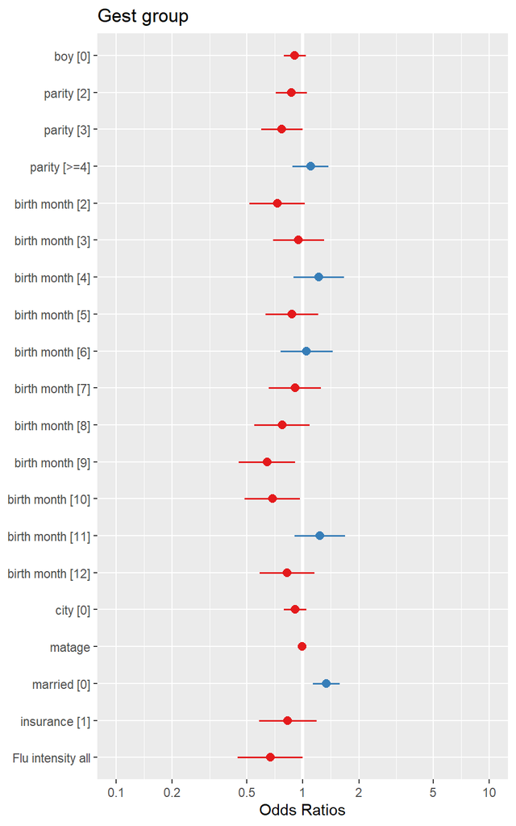

# Stillborn

Data Bern

| year | alive | stillborn | perc_stillborn | alive_bfs | stillborn_bfs | perc_stillborn_bfs | Perc_diff |
| --- | --- | --- | --- | --- | --- | --- | --- |
| 1912 | 619 | 30 | 4.62 | 92196 | 2975 | 3.13 | -1.49 |
| 1913 | 719 | 29 | 3.88 | 89757 | 2846 | 3.07 | -0.81 |
| 1914 | 754 | 38 | 4.80 | 87330 | 2798 | 3.10 | -1.70 |
| 1915 | 705 | 31 | 4.21 | 75545 | 2386 | 3.06 | -1.15 |
| 1916 | 779 | 27 | 3.35 | 73660 | 2225 | 2.93 | -0.42 |
| 1917 | 799 | 30 | 3.62 | 72065 | 2060 | 2.78 | -0.84 |
| 1918 | 742 | 36 | 4.63 | 72658 | 2226 | 2.97 | -1.66 |
| 1919 | 619 | 42 | 6.35 | 72125 | 2080 | 2.80 | -3.55 |
| 1920 | 774 | 32 | 3.97 | 81190 | 2433 | 2.91 | -1.06 |
| 1921 | 773 | 38 | 4.69 | 80808 | 2365 | 2.84 | -1.85 |
| 1922 | 664 | 41 | 5.82 | 76290 | 2246 | 2.86 | -2.96 |

High multicollinearity between year and exposure sum and year and flu intensity. Therefor only one variable is used.

## unadjusted

### Year

```
##
## Call:
## glm(formula = formula, family = binomial(link = "logit"), data = datared)
##
## Deviance Residuals:
##     Min       1Q   Median       3Q      Max
## -0.3624  -0.3136  -0.3078  -0.2715   2.6062
##
## Coefficients:
##             Estimate Std. Error z value Pr(>|z|)
## (Intercept) -2.98781    0.16626 -17.971   <2e-16 ***
## year1915    -0.13640    0.24763  -0.551    0.582
## year1916    -0.37437    0.25683  -1.458    0.145
## year1917    -0.29436    0.24945  -1.180    0.238
## year1918    -0.03802    0.23826  -0.160    0.873
## year1919     0.29737    0.23036   1.291    0.197
## year1920    -0.19803    0.24532  -0.807    0.420
## year1921    -0.02489    0.23506  -0.106    0.916
## year1922     0.20310    0.23138   0.878    0.380
## ---
## Signif. codes:  0 '***' 0.001 '**' 0.01 '*' 0.05 '.' 0.1 ' ' 1
##
## (Dispersion parameter for binomial family taken to be 1)
##
##     Null deviance: 2562.3  on 6923  degrees of freedom
## Residual deviance: 2549.7  on 6915  degrees of freedom
## AIC: 2567.7
##
## Number of Fisher Scoring iterations: 6
```

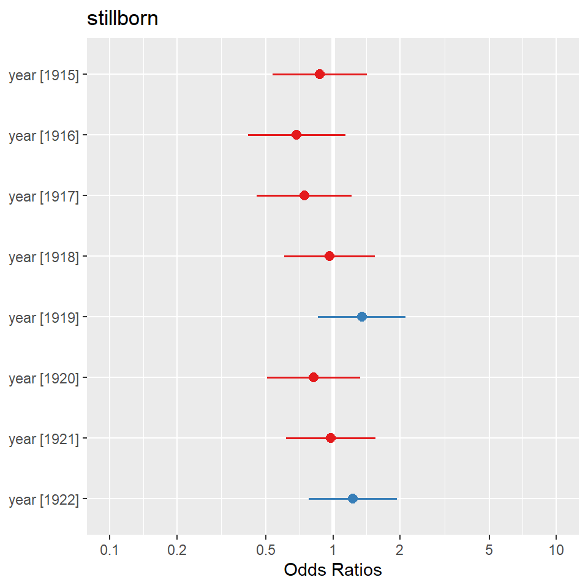

### Flu Intensity

```
##
## Call:
## glm(formula = formula, family = binomial(link = "logit"), data = datared)
##
## Deviance Residuals:
##     Min       1Q   Median       3Q      Max
## -0.4157  -0.2977  -0.2977  -0.2977   2.5055
##
## Coefficients:
##                   Estimate Std. Error z value Pr(>|z|)
## (Intercept)       -3.09444    0.06201 -49.900  < 2e-16 ***
## Flu_intensity_all  0.70315    0.26628   2.641  0.00827 **
## ---
## Signif. codes:  0 '***' 0.001 '**' 0.01 '*' 0.05 '.' 0.1 ' ' 1
##
## (Dispersion parameter for binomial family taken to be 1)
##
##     Null deviance: 2562.3  on 6923  degrees of freedom
## Residual deviance: 2556.0  on 6922  degrees of freedom
## AIC: 2560
##
## Number of Fisher Scoring iterations: 6
```

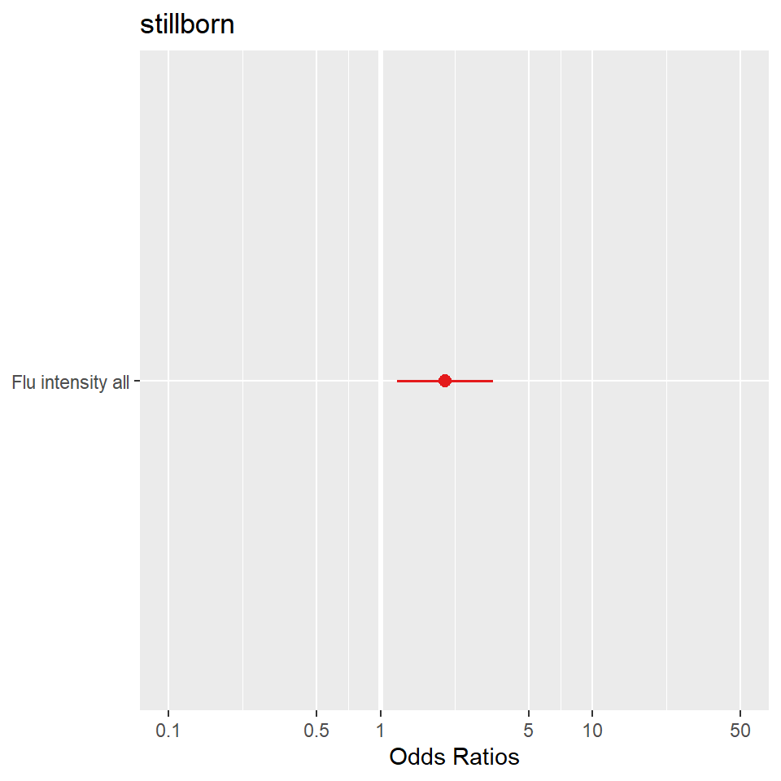

## adjusted

```
##
## Call:
## glm(formula = formula, family = binomial(link = "logit"), data = datared)
##
## Deviance Residuals:
##     Min       1Q   Median       3Q      Max
## -0.7037  -0.3270  -0.2632  -0.2233   2.9601
##
## Coefficients:
##              Estimate Std. Error z value Pr(>|z|)
## (Intercept) -5.093961   0.370305 -13.756  < 2e-16 ***
## year1915    -0.158557   0.251537  -0.630   0.5285
## year1916    -0.400709   0.263167  -1.523   0.1278
## year1917    -0.299250   0.253005  -1.183   0.2369
## year1918    -0.052927   0.245519  -0.216   0.8293
## year1919     0.292135   0.234297   1.247   0.2124
## year1920    -0.164648   0.249305  -0.660   0.5090
## year1921    -0.070017   0.240747  -0.291   0.7712
## year1922     0.194239   0.237044   0.819   0.4125
## boy0         0.006106   0.117650   0.052   0.9586
## parity2     -0.140839   0.178800  -0.788   0.4309
## parity3     -0.457349   0.239633  -1.909   0.0563 .
## parity>=4    0.140782   0.175465   0.802   0.4224
## birth_month  0.008122   0.017186   0.473   0.6365
## matage       0.068115   0.010574   6.442 1.18e-10 ***
## married0     0.012017   0.160027   0.075   0.9401
## city0        0.201141   0.119949   1.677   0.0936 .
## insurance1  -0.418378   0.320161  -1.307   0.1913
## ---
## Signif. codes:  0 '***' 0.001 '**' 0.01 '*' 0.05 '.' 0.1 ' ' 1
##
## (Dispersion parameter for binomial family taken to be 1)
##
##     Null deviance: 2523.4  on 6899  degrees of freedom
## Residual deviance: 2419.7  on 6882  degrees of freedom
##   (24 Beobachtungen als fehlend gelöscht)
## AIC: 2455.7
##
## Number of Fisher Scoring iterations: 6
```

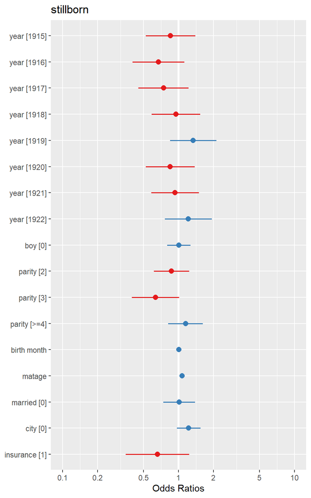

### Flu intensity

```
##
## Call:
## glm(formula = formula, family = binomial(link = "logit"), data = datared)
##
## Deviance Residuals:
##     Min       1Q   Median       3Q      Max
## -0.7436  -0.3270  -0.2617  -0.2268   2.9146
##
## Coefficients:
##                    Estimate Std. Error z value Pr(>|z|)
## (Intercept)       -5.216043   0.333716 -15.630  < 2e-16 ***
## boy0               0.001780   0.117561   0.015   0.9879
## parity2           -0.151124   0.178561  -0.846   0.3974
## parity3           -0.475241   0.239352  -1.986   0.0471 *
## parity>=4          0.129177   0.175535   0.736   0.4618
## birth_month        0.011265   0.017185   0.655   0.5122
## matage             0.067755   0.010568   6.412 1.44e-10 ***
## married0           0.008808   0.160009   0.055   0.9561
## city0              0.208244   0.119715   1.739   0.0819 .
## insurance1        -0.392350   0.319718  -1.227   0.2198
## Flu_intensity_all  0.713579   0.271979   2.624   0.0087 **
## ---
## Signif. codes:  0 '***' 0.001 '**' 0.01 '*' 0.05 '.' 0.1 ' ' 1
##
## (Dispersion parameter for binomial family taken to be 1)
##
##     Null deviance: 2523.4  on 6899  degrees of freedom
## Residual deviance: 2425.8  on 6889  degrees of freedom
##   (24 Beobachtungen als fehlend gelöscht)
## AIC: 2447.8
##
## Number of Fisher Scoring iterations: 6
```

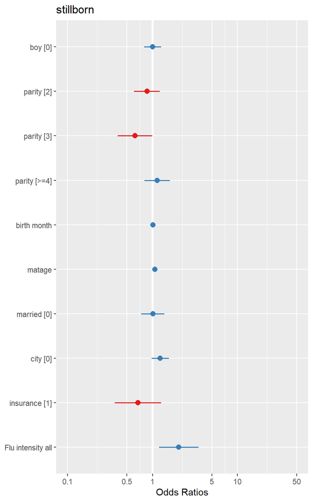